# ADRECMO — DPP3

KIMMOUN DUARTE

2026-01-15

# 1 STATISTICAL METHOD

Continuous variables are reported as median and interquartile range [IQR], whereas categorical variables are presented as counts and percentages. Baseline comparisons were performed by stratifying patients according to the median pre-implantation cDPP3 concentration into below median and above median cDPP3 groups. Considering the sample size and the exploratory, post hoc nature of this study, between-group differences are reported as Hodges–Lehmann estimates with 95% confidence intervals (derived from the Wilcoxon rank-sum test) for continuous variables, and as absolute differences in group proportions with 95% confidence intervals (estimated using the Agresti–Caffo method) for categorical variables. Continuous variables with a skewed distribution were log transformed for all subsequent models. Correlations between cDPP3 concentrations and continuous variables were evaluated using Spearman test. Variables measured at three predefined time points were compared using linear mixed-effects models with Kenward–Roger correction. Residuals of the models were checked. 30-day survival was evaluated in high and low cDPP3 groups drawing Kaplan–Meier curves. Heart transplantation and long-term mechanical circulatory support were treated as censoring events. A multivariable Cox model investigating the association between cDPP3 and the 30-day survival was performed: considering the sample size and the fact that cDPP3 is regarded as one of the main drivers highly correlated with clinico-biological severity and outcome, confounders were selected a priori and included cardiac arrest before VA-ECMO, cause of cardiogenic shock (ischemic or non-ischemic), the delay between ICU admission and VA-ECMO implantation. Model assumption was checked using Schoenfeld residuals. All statistical analyses were performed using R (version 4.5.2 (2025-10-31)). A two-sided p-value < 0.05 was considered statistically significant and as the results were considered exploratory no adjustment for alpha multiplicity was performed.

# 2 GLOBAL SETUP

# 3 TABLE 1: Baseline characteristics by DPP3 median

```r
ft_t1
```

Table 1: Characteristics of the population by circulating DPP3 median measured at time of VA-ECMO implantation

| Variables | Missing | cDPP3>73 ng/mL | cDPP3≤73 ng/mL | Group difference [95% CI] |
| --- | --- | --- | --- | --- |
| n |  | 23 | 24 | NA |
| Demographics |  |  |  |  |
| Age (years) | 0 | 60.0 [53.0 – 67.5] | 59.0 [48.8 – 64.5] | 1 [-6 – 9] |
| Gender = Female (%) | 0 | 5 (21.7) | 2 ( 8.3) | -13 [-33 – +8] |
| Body Mass Index (kg/m²) | 3 | 28.1 [22.9 – 31.9] | 26.0 [24.9 – 28.6] | 2 [-2 – 6] |
| Medical History |  |  |  |  |
| Hypertension (%) | 0 | 10 (43.5) | 8 (33.3) | -10 [-36 – +17] |
| Diabetes Mellitus (%) | 0 | 5 (21.7) | 4 (16.7) | -5 [-27 – +18] |
| Heart Failure (%) | 0 | 7 (30.4) | 9 (37.5) | +7 [-20 – +33] |
| Chronic Kidney Disease (%) | 0 | 4 (17.4) | 1 ( 4.2) | -13 [-31 – +6] |
| Chronic Respiratory Disease (%) | 0 | 2 ( 8.7) | 1 ( 4.2) | -4 [-21 – +12] |
| Neurological Deficit (%) | 0 | 4 (17.4) | 0 ( 0.0) | -17 [-34 – +1] |
| Immunosuppression (%) | 0 | 2 ( 8.7) | 2 ( 8.3) | -0 [-18 – +17] |
| Prior-adrenergic medications |  |  |  |  |
| Beta-blocker (%) | 0 | 11 (47.8) | 11 (45.8) | -2 [-29 – +26] |
| Alpha-blocker (%) | 0 | 2 ( 8.7) | 1 ( 4.2) | -4 [-21 – +12] |
| Cardiogenic shock cause |  |  |  |  |
| Non-ischemic (%) | 0 | 8 (34.8) | 8 (33.3) | -1 [-28 – +25] |
| Ischemic (%) | 0 | 15 (65.2) | 16 (66.7) | +1 [-25 – +28] |
| Cardiac Arrest Before Cannulation (%) | 0 | 15 (65.2) | 10 (41.7) | -24 [-48 – +5] |
| Clinical parameters |  |  |  |  |
| Systolic Blood Pressure (mmHg) | 0 | 92.0 [84.0 – 104.0] | 101.5 [91.8 – 116.2] | -10 [-21 – 0] |
| Diastolic Blood Pressure (mmHg) | 0 | 63.0 [59.5 – 68.0] | 67.0 [56.0 – 72.2] | -3 [-9 – 6] |
| Mean Arterial Pressure (mmHg) | 0 | 71.0 [68.0 – 78.5] | 76.5 [68.8 – 87.0] | -5 [-12 – 2] |
| Heart Rate (bpm) | 0 | 96.0 [86.0 – 125.5] | 95.5 [84.0 – 103.5] | 4 [-7 – 21] |
| Ejection Fraction (%) | 4 | 17.5 [13.8 – 25.2] | 20.0 [15.0 – 20.0] | -0 [-5 – 5] |
| Aortic Velocity Time Integral (cm) | 8 | 8.0 [5.5 – 9.0] | 7.0 [6.0 – 8.0] | 0 [-2 – 2] |
| Mechanical ventilation (%) | 0 | 19 (82.6) | 15 (62.5) | -20 [-43 – +6] |
| Biological assessment |  |  |  |  |
| Bilirubin (mg/dL) | 1 | 22.0 [15.0 – 38.0] | 20.0 [11.0 – 39.0] | 2 [-8 – 10] |
| High Sensitivity Troponin I (ng/L) | 13 | 35477.0 [915.0 – 319961.0] | 1613.0 [191.2 – 107779.0] | 808 [-37072 – 140244] |
| NT-proBNP (pg/mL) | 24 | 18949.0 [7631.0 – 28778.0] | 4240.0 [1669.5 – 9305.0] | 13428 [-1811 – 25423] |
| Platelet Count (10⁹/L) | 0 | 139.0 [98.0 – 272.5] | 208.5 [149.5 – 272.2] | -40 [-96 – 26] |

Data are expressed in n(%) for categorical variables and median [25th–75th] for continuous variables.Between-group differences are reported as Hodges–Lehmann estimates with 95% confidence intervals for continuous variables, and as absolute differences in group proportions with 95% confidence intervals (estimated using the Agresti–Caffo method) for categorical variables.

# 4 TABLE 2: Outcome according to cDDP3 median

```r
ft_t2
```

Table 2: Outcomes according to circulating DPP3 median measured at time of VA-ECMO implantation

| Variables | cDPP3>73 ng/mL | cDPP3≤73 ng/mL | Group difference [95% CI] |
| --- | --- | --- | --- |
| n | 23 | 24 | NA |
| ECMO Duration (days) | 7 [4 – 10] | 5 [3 – 9] | 0 [-2 – 3] |
| ECMO Duration in weaned (days) | 7 [4 – 10] | 4 [3 – 6] | 2 [-1 – 6] |
| ECMO Duration in deceased (days) | 5 [3 – 7] | 7 [4 – 10] | -1 [-5 – 2] |
| Intra-Aortic Balloon Pump (%) | 11 (48) | 16 (67) | -19 [-44 – +9] |
| Renal Replacement Therapy (%) | 11 (48) | 2 ( 8) | +40 [+13 – +60] |
| Duration of Mechanical Ventilation (days) | 8 [4 – 16] | 3 [2 – 6] | 4 [1 – 9] |
| ICU Length of Stay (days) | 15 [5 – 34] | 14 [7 – 17] | 2 [-4 – 12] |
| Outcome |  |  |  |
| Death in ICU (%) | 13 (56) | 7 (29) | +27 [-1 – +52] |
| Bridge to LVAD (%) | 2 ( 9) | 2 ( 8) | +0 [-17 – +18] |
| Bridge to Transplant (%) | 1 ( 4) | 1 ( 4) | +0 [-14 – +15] |
| ECMO Weaning (%) | 7 (30) | 14 (58) | -28 [-52 – +1] |
| 30-day Mortality (%) | 14 (61) | 8 (33) | +28 [-1 – +52] |

Data are expressed in n(%) for categorical variables and median [25th–75th] for continuous variables.Between-group differences are reported as Hodges–Lehmann estimates with 95% confidence intervals for continuous variables, and as absolute differences in group proportions with 95% confidence intervals (estimated using the Agresti–Caffo method) for categorical variables.

# 5 FIGURE 1: Association between circulating DPP3 concentrations and organ dysfunction at VA-ECMO implantation. Patients were stratified according to baseline circulating DPP3 (cDPP3) concentrations using the median value (73 ng/mL).

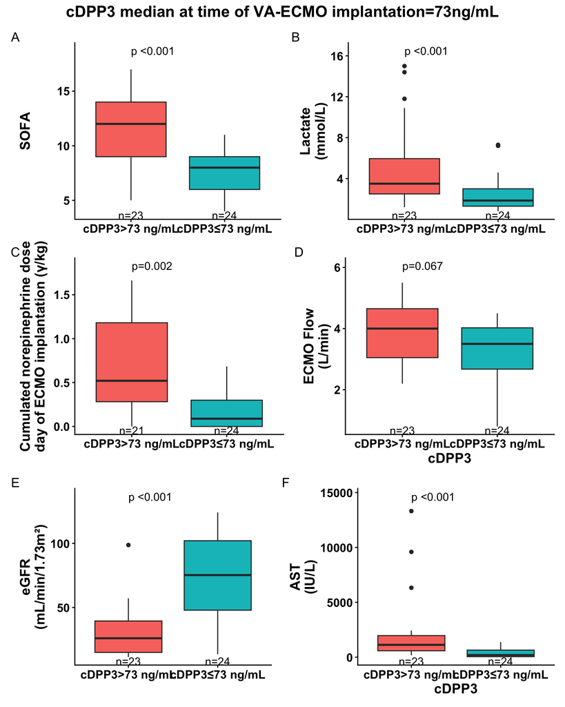

FIGURE 1: Association between circulating DPP3 concentrations and organ dysfunction at VA-ECMO implantation. Patients were stratified according to baseline circulating DPP3 (cDPP3) concentrations using the median value (73 ng/mL).

# 6 FIGURE 2: Association between baseline circulating DPP3 concentrations measured at VA-ECMO implantation and 30-day survival in patients with cardiogenic shock supported with VA-ECMO.

[figure not shown]

FIGURE 2: Association between baseline circulating DPP3 concentrations measured at VA-ECMo implantation and 30-day survival in patients with cardiogenic shock supported with VA-ECMO.

# 7 FIGURE 3: Time course of circulating DPP3 concentrations in patients with cardiogenic shock supported with VA-ECMO.

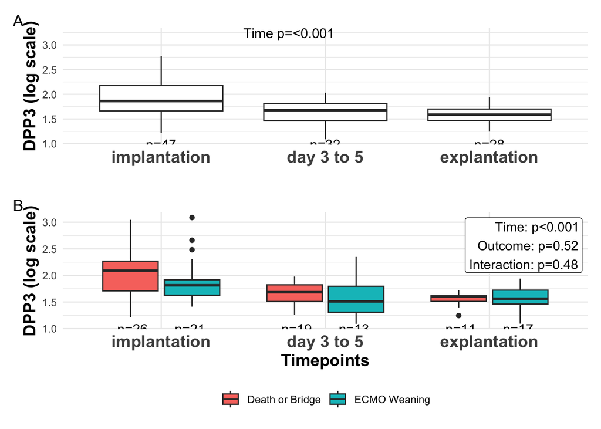

FIGURE 3: Time course of circulating DPP3 concentrations in patients with cardiogenic shock supported with VA-ECMO.

# 8 FIGURE 4: Associations between changes in circulating DPP3 concentrations and changes in markers of organ dysfunction from VA-ECMO implantation to day 3 to 5 while on VA-ECMO.

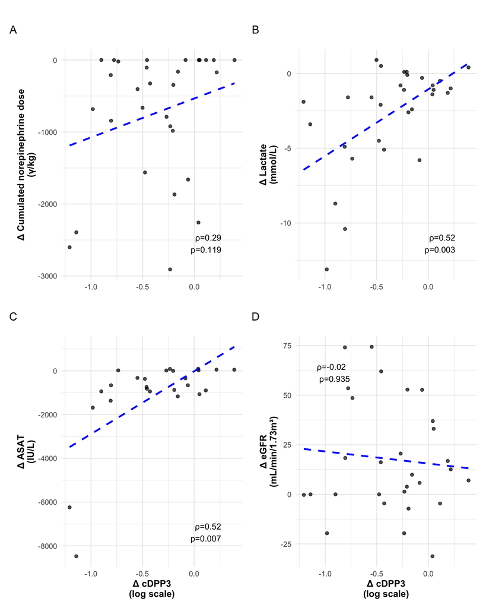

FIGURE 4 : Associations between changes in circulating DPP3 concentrations and changes in markers of organ dysfunction from VA-ECMO implantation to day 3 to 5 while on VA-ECMO.

# 9 FIGURE 5: Individual trajectories of circulating DPP3 concentrations according to haptoglobin dynamics from VA-ECMO implantation to day 3 to 5 while on VA-ECMO.

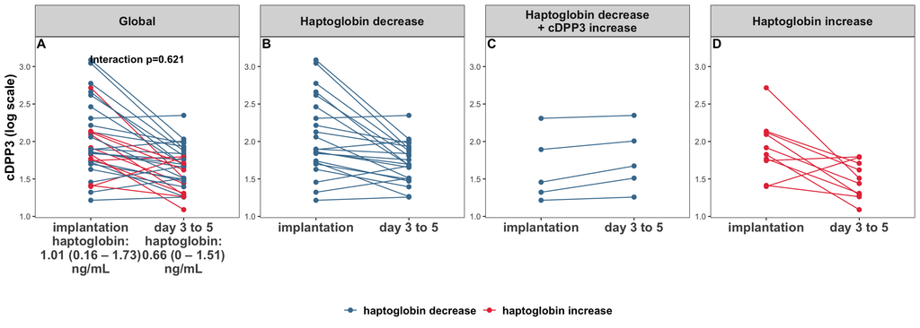

FIGURE 5 : Individual trajectories of circulating DPP3 concentrations according to haptoglobin dynamics from VA-ECMO implantation to day 3 to 5 while on VA-ECMO.